# izbrane-teme-Jan22

Patrik Kojanec, Matej Pičulin, Jana Faganeli

26/01/2022

# 1.del - Povezovanje do SQL baz in vzorčenje

### Povezava na SQL bazo

Za delo z SQL bazami potrebujemo paket `DBI`, ki komunicira med R-jem in sistemi za upravljanje z podatkovnimi bazami. Poleg tega potrebujemo še paket za dotično bazo. V tem primeru bomo uporabljali MariaDB in paket `RMariaDB`, obstajajo pa seveda še drugi in delo z njimi je identično ali zelo podobno. Nekaj ostalih paketov je `RMySQL`, `RPostgreSQL`, `RSQLite`, `ROracle`, `odbc` itd.

Naložimo potrebne pakete:

```r
library(tidyverse)
library(dbplyr)
library(DBI)
library(RMariaDB)
```

Najprej se moramo na bazo povezati. To storimo s funkcijo `dbConnect()`:

```r
con <- dbConnect(RMariaDB::MariaDB(),
                 user = "urejanje",
                 password = "podatkov",
                 dbname = "delavnica",
                 host = "localhost")
```

V tem primeru smo se povezali na lokalno bazo *delavnica* z uporabnikom *urejanje* in geslom *podatkov*. Prvi argument funkcije je vedno funkcija za povezavo naše dotične baze.

Sedaj si poglejmo, kako lahko tabelo iz R-ja zapišemo v našo bazo. To storimo z ukazom `dbWriteTable()`.

```r
accounts <- read.csv2("./data-raw/financial/account.csv")
dbWriteTable(con, "accounts", accounts, overwrite = T) #DBI verzija
```

Ko imamo v bazi svoje podatke, lahko po njih delamo SQL poizvedbe. Osnovna funkcija je `dbGetQuery()`, ki zahteva povezavo in poizvedbo zapisano kot navaden tekst.

```r
res <- dbGetQuery(con, "SELECT trans_id, type, balance
                 FROM transactions_small
                 WHERE balance > 100000")
head(tibble(res))
```

```
## # A tibble: 6 x 3
##   trans_id type        balance
##      <int> <chr>         <int>
## 1   180247 EXPENDITURE  109145
## 2   183557 INCOME       126891
## 3  2956247 INCOME       123324
## 4  1006586 INCOME       116108
## 5  2355618 EXPENDITURE  100800
## 6  1086644 INCOME       126628
```

Vidimo, da nam poizvedba vrne pričakovani rezultat. Če želimo prenesti celotno tabelo imamo na voljo funkcijo `dbReadTable()`. Z uporabo le te preberimo podatke o transakcijah, ki smo jih za potrebe demonstracije že predhodno naložili. Podatki so enako kot na drugem predavanju.

```r
trans <- dbReadTable(con, "transactions_small") # Preberemo podatke iz baze v R.
trans <- tibble(trans)
head(trans)
```

```
## # A tibble: 6 x 10
##   trans_id account_id date       type   operation  amount balance k_symbol bank
##      <int>      <int> <chr>      <chr>  <chr>       <int>   <int> <chr>    <chr>
## 1   736882       2517 1997-07-17 CHOICE CHOICE      21992   22279 <NA>     <NA>
## 2   201830        686 1997-05-08 INCOME DEPOSIT     10533   18473 <NA>     <NA>
## 3  3158278      10478 1998-01-29 EXPEN~ CHOICE       2100    8821 <NA>     <NA>
## 4    41116        135 1994-05-09 EXPEN~ CHOICE       2900   21513 <NA>     <NA>
## 5  1046207       3578 1996-09-08 EXPEN~ TRANSFER ~   4051   51755 SIPO     KL
## 6   875501       2982 1997-04-30 EXPEN~ CHOICE      12100   41859 <NA>     <NA>
## # ... with 1 more variable: account <int>
```

Tudi paket `dplyr` ima funkcije za delo z bazami, ki vedno vrnejo tibble, hkrati pa nam omogočajo **pisati** SQL ukaze z pipe operacijo.

Dostop do tabele na bazi lahko omogočimo s funkcijo `tbl`. Ta funkcija podatkov ne prenese ampak naredi le kazalec na tabelo na bazi!

```r
razpredelnica_na_bazi <- tbl(con, "transactions_small") # S tbl() dostopamo do razpredelnice na bazi.
razpredelnica_na_bazi
```

```
## # A tibble: 20,000 x 10
##    trans_id account_id date       type   operation amount balance k_symbol bank
##       <int>      <int> <chr>      <chr>  <chr>      <int>   <int> <chr>    <chr>
##  1   736882       2517 1997-07-17 CHOICE CHOICE     21992   22279 <NA>     <NA>
##  2   201830        686 1997-05-08 INCOME DEPOSIT    10533   18473 <NA>     <NA>
##  3  3158278      10478 1998-01-29 EXPEN~ CHOICE      2100    8821 <NA>     <NA>
##  4    41116        135 1994-05-09 EXPEN~ CHOICE      2900   21513 <NA>     <NA>
##  5  1046207       3578 1996-09-08 EXPEN~ TRANSFER~   4051   51755 SIPO     KL
##  6   875501       2982 1997-04-30 EXPEN~ CHOICE     12100   41859 <NA>     <NA>
##  7   893918       3047 1996-11-30 EXPEN~ CHOICE        15   24788 SERVICES <NA>
##  8  3442751       1543 1998-07-31 INCOME <NA>          71   17153 UROK     <NA>
##  9   462371       1571 1998-08-25 EXPEN~ CHOICE      2760   25770 <NA>     <NA>
## 10  1028586       3513 1993-10-12 EXPEN~ TRANSFER~   4507   31227 SIPO     KL
## # ... with 19,990 more rows, and 1 more variable: account <int>
```

Sedaj naredimo kratko poizvedbo, kot smo jih navajeni delati z *tidyverse* paketi.

```r
povzemi <- razpredelnica_na_bazi %>%
  group_by(type, operation) %>%
  summarise(stevilo = n())
povzemi %>% show_query() # Prikaže prevedeno kodo v SQL.
```

```
## <SQL>
## SELECT `type`, `operation`, COUNT(*) AS `stevilo`
## FROM `transactions_small`
## GROUP BY `type`, `operation`
```

Funkcija `show_query()` nam pokaže SQL stavek, ki se je izvedel direktno na bazi, da dobimo želeni rezultat. To pomeni, da se je zgornji izraz le prevedel v SQL poizvedbo in bil poslan bazi.

Sedaj še shranimo povzetek in zapremo povezvo do baze.

```r
povzetek <- povzemi %>% collect()
povzetek
```

```
## # A tibble: 7 x 3
##   type        operation           stevilo
##   <chr>       <chr>               <int64>
## 1 CHOICE      CHOICE                  290
## 2 EXPENDITURE CHOICE                 7975
## 3 EXPENDITURE CHOICE KARTOU           146
## 4 EXPENDITURE TRANSFER TO ACCOUNT    3877
## 5 INCOME      <NA>                   3501
## 6 INCOME      DEPOSIT                2943
## 7 INCOME      TRANSFER FROM UCTU     1268
```

```r
dbDisconnect(con) # Zapremo povezavo do baze.
```

Ko bazo zapremo vidimo, da so shranjeni podatki še na voljo, kazalci na bazo pa se izgubijo.

```r
#povzetek še imamo
povzetek
```

```
## # A tibble: 7 x 3
##   type        operation           stevilo
##   <chr>       <chr>               <int64>
## 1 CHOICE      CHOICE                  290
## 2 EXPENDITURE CHOICE                 7975
## 3 EXPENDITURE CHOICE KARTOU           146
## 4 EXPENDITURE TRANSFER TO ACCOUNT    3877
## 5 INCOME      <NA>                   3501
## 6 INCOME      DEPOSIT                2943
## 7 INCOME      TRANSFER FROM UCTU     1268
```

```r
#kazalca poizvedbe ni več
povzemi
```

```
## Error: external pointer is not valid
```

```r
#razpredelnica ni več dostopna
razpredelnica_na_bazi
```

```
## Error: external pointer is not valid
```

```r
#podatke o transakcijah še vedno imamo v R-ju
head(trans)
```

```
## # A tibble: 6 x 10
##   trans_id account_id date       type   operation  amount balance k_symbol bank
##      <int>      <int> <chr>      <chr>  <chr>       <int>   <int> <chr>    <chr>
## 1   736882       2517 1997-07-17 CHOICE CHOICE      21992   22279 <NA>     <NA>
## 2   201830        686 1997-05-08 INCOME DEPOSIT     10533   18473 <NA>     <NA>
## 3  3158278      10478 1998-01-29 EXPEN~ CHOICE       2100    8821 <NA>     <NA>
## 4    41116        135 1994-05-09 EXPEN~ CHOICE       2900   21513 <NA>     <NA>
## 5  1046207       3578 1996-09-08 EXPEN~ TRANSFER ~   4051   51755 SIPO     KL
## 6   875501       2982 1997-04-30 EXPEN~ CHOICE      12100   41859 <NA>     <NA>
## # ... with 1 more variable: account <int>
```

Paket `odbc` omogoča povezavo do različnih baz, hkrati pa je tudi povezan z RStudijem, kar lahko vidite v desnem zgornjem oknu pod zavihkom connections.

Poglejmo katere gonilnike ima odbc na voljo in se z enim povežimo na bazo. Pozor, dotični gonilnik je potrebno namestiti. Dobite ga [tukaj](https://dev.mysql.com/downloads/connector/odbc/).

```r
library("odbc")
sort(unique(odbcListDrivers()[[1]]))
```

```
## [1] "Microsoft Access Driver (*.mdb, *.accdb)"
## [2] "Microsoft Access Text Driver (*.txt, *.csv)"
## [3] "Microsoft Excel Driver (*.xls, *.xlsx, *.xlsm, *.xlsb)"
## [4] "MySQL ODBC 8.0 ANSI Driver"
## [5] "MySQL ODBC 8.0 Unicode Driver"
## [6] "SQL Server"
```

```r
povezava <- dbConnect(odbc(),
                      driver = "MySQL ODBC 8.0 ANSI Driver",
                      user = "urejanje",
                      password = "podatkov",
                      dbname = "delavnica",
                      host = "localhost")
dbDisconnect(povezava)
```

### Vzorčenje

Najbolj osnovna in najbolj uporabna funkcija za vzorčenje tabel v R-ju je `sample`. Omogoča vračanje elementov s ali brez ponavljanja in tudi uporabo uteži.

```r
sample(1:10, 5)
```

```
## [1]  4  6 10  2  3
```

```r
sample(1:10, 5, replace = T)
```

```
## [1]  2 10  6  8  5
```

```r
sample(1:10, 5, prob = c(20, 20, 15, 15, 10, 10, 5, 5, 1, 1))
```

```
## [1] 2 4 6 7 1
```

Z uporabo te funkcije sedaj vzorčimo 1000 vzrocev iz tabele trans, ki ima 20000 primerov.

```r
trans1000 <- trans[sample(1:nrow(trans), 1000),]
```

Takšno vzorčenje je v praksi reprezantitivno, če imamo dovolj podatkov in imamo dokaj enakomerno število vrednosti pri vsaki spremenljivki.

Poglejmo, kaj se je zgodilo z distribucijo izbrane nominalne spremenljivke.

```r
table(trans$type)/nrow(trans)
```

```
##
##      CHOICE EXPENDITURE      INCOME
##      0.0145      0.5999      0.3856
```

```r
table(trans1000$type)/nrow(trans1000)
```

```
##
##      CHOICE EXPENDITURE      INCOME
##       0.013       0.592       0.395
```

Opazimo, lahko da je ujemanje OK, vendar ne idealno. Pogledamo lahko tudi, če smo pravilno vzorčili zvezno spremenljivko, pri tem pa jo bomo za lažji prikaz diskretizirali in prikazali obe distribuciji.

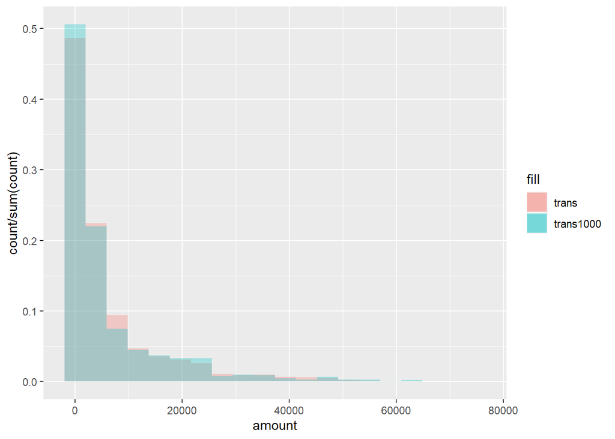

```r
ggplot(trans, aes(x = amount, fill = "trans")) +
  geom_histogram(aes(y=..count../sum(..count..)), alpha = 0.3, bins = 20) +
  geom_histogram(data = trans1000, aes(y=..count../sum(..count..), fill = "trans1000"),
                  alpha = 0.3, bins = 20)
```

Opazimo, da je tudi v tem primeru vzročenje primerno.

## Stratificirano vzorčenje

Če želimo distribucijo neke spremenljivke ohraniti čim bolj reprezantitivno lahko uporabimo straticificirano vzorčenje.

Najprej za spremenljivko *type* izračunajmo koliko primerov bi moralo biti izbranih za vsako vrednost, če bi želeli imeti enako distribucijo kot v originalnih podatkih.

```r
dist <- table(trans$type)/nrow(trans)*1000
dist <- round(dist)
dist
```

```
##
##      CHOICE EXPENDITURE      INCOME
##          14         600         386
```

Spodaj je še funkcija, ki nam vrne isto, hkrati pa pazi še za morebitne napake pri zaokroževanju.

```r
calculate_subsamples_n <- function(data, colName, n){
  dist <- table(trans$type)/nrow(trans)*n
  dist <- round(dist)
  #dodatno preverjanje, ker zaradi zaokroževanja
  #lahko pride do manjših odstopanj v n-ju
  #največji vrednosti prištejemo oz. odštejemo dodatne primere
  max_value <- which.max(dist)
  odstopanje <- n - sum(dist)
  if(odstopanje > 0){
    dist[max_value] <- dist[max_value] - odstopanje
  }else if(odstopanje < 0){
    dist[max_value] <- dist[max_value] + odstopanje
  }
  dist
}

calculate_subsamples_n(trans, "type", 1000)
```

```
##
##      CHOICE EXPENDITURE      INCOME
##          14         600         386
```

Sedaj lahko sami izberemo primerno število primerov glede na vrednost spremenljivke in jih nato združimo.

```r
select_n_rows <- function(data, n){
  data[sample(1:nrow(data), n),]
}

t1 <- trans %>% filter(type == "CHOICE") %>% select_n_rows(14)
t2 <- trans %>% filter(type == "EXPENDITURE") %>% select_n_rows(600)
t3 <- trans %>% filter(type == "INCOME") %>% select_n_rows(386)

t <- union(t1, union(t2, t3))

table(trans$type)/nrow(trans)
```

```
##
##      CHOICE EXPENDITURE      INCOME
##      0.0145      0.5999      0.3856
```

```r
table(t$type)/nrow(t)
```

```
##
##      CHOICE EXPENDITURE      INCOME
##       0.014       0.600       0.386
```

V tem primeru je bilo to še dokaj preprosto, da smo brez večjih težav lahko to spisali samo. Vendar, ta pristop ohranja le distribucijo po izbrani spremenljivi, ostale pa lahko tudi nekoliko bolj pokvari.

Če želimo stratificirano vzorčenje uporabiti po več spremenljivkah je bolje, da uporabimo paket `splitstackshape`, ki omogoča več različnih vzorčenj.

Najprej vzorčimo samo po spremenljivki *type* in vidimo, da distribucija spremeljivke *operation* ni najboljša.

```r
library(splitstackshape)
trans5p <- tibble(stratified(trans, group = "type", size = 0.05))
table(trans$type)/nrow(trans)
```

```
##
##      CHOICE EXPENDITURE      INCOME
##      0.0145      0.5999      0.3856
```

```r
table(trans5p$type)/nrow(trans5p)
```

```
##
##      CHOICE EXPENDITURE      INCOME
##       0.014       0.600       0.386
```

```r
table(trans$operation)/nrow(trans)
```

```
##
##              CHOICE       CHOICE KARTOU             DEPOSIT  TRANSFER FROM UCTU
##             0.41325             0.00730             0.14715             0.06340
## TRANSFER TO ACCOUNT
##             0.19385
```

```r
table(trans5p$operation)/nrow(trans5p)
```

```
##
##              CHOICE       CHOICE KARTOU             DEPOSIT  TRANSFER FROM UCTU
##               0.441               0.005               0.143               0.064
## TRANSFER TO ACCOUNT
##               0.168
```

Sedaj ponovimo postopek, s tem, da ohranimo obe distribuciji.

```r
trans5p <- tibble(stratified(trans, group = c("type", "operation"), size = 0.05))
table(trans$type)/nrow(trans)
```

```
##
##      CHOICE EXPENDITURE      INCOME
##      0.0145      0.5999      0.3856
```

```r
table(trans5p$type)/nrow(trans5p)
```

```
##
##      CHOICE EXPENDITURE      INCOME
##  0.01401401  0.60060060  0.38538539
```

```r
table(trans$operation)/nrow(trans)
```

```
##
##              CHOICE       CHOICE KARTOU             DEPOSIT  TRANSFER FROM UCTU
##             0.41325             0.00730             0.14715             0.06340
## TRANSFER TO ACCOUNT
##             0.19385
```

```r
table(trans5p$operation)/nrow(trans5p)
```

```
##
##              CHOICE       CHOICE KARTOU             DEPOSIT  TRANSFER FROM UCTU
##         0.413413413         0.007007007         0.147147147         0.063063063
## TRANSFER TO ACCOUNT
##         0.194194194
```

# 2.del - Exploratory data analysis

V tem delu bomo simulirali Exploratory Data Analysis (EDA). Uporablili bomo statistične podatke o Covidu v Sloveniji, ki so na voljo na spletni strani Sledilnika. Cilj je, da se spoznamo s podatki, jih preuredimo v obliko za lažje delo in poskušamo izluščiti trende iz njih. Podatke bomo za potrebe prikazovanja nekaterih funkcij tudi dodatno še nekoliko popačili z manjkajočimi vrednostmi.

## Naložimo Podatke

Najprej naložimo podatke. To lahko storimo z uporabo funkcije `curl`, ki podatke prenese kar iz uradne strani.

```r
library(tidyverse)
library(curl)
library(lubridate)
set.seed(1234)

df <- read_csv(curl("https://raw.githubusercontent.com/sledilnik/data/master/csv/stats.csv"))
```

Če smo pozorni na izpis vidimo, da imamo 129 zveznih atributov, 6 logičnih, en datum in en nominalni atribut.

Poglejmo, kako ti podatki izgledajo:

```r
df
```

```
## # A tibble: 703 x 137
##      day date       phase tests.performed.to~ tests.performed tests.positive.to~
##    <dbl> <date>     <chr>               <dbl>           <dbl>              <dbl>
##  1    -8 2020-02-24 F0                     38              18                 NA
##  2    -7 2020-02-25 F0                     59              21                 NA
##  3    -6 2020-02-26 F0                    100              41                 NA
##  4    -5 2020-02-27 F0                    143              43                 NA
##  5    -4 2020-02-28 F0                    178              35                 NA
##  6    -3 2020-02-29 F0                    194              16                 NA
##  7    -2 2020-03-01 F0                    211              17                 NA
##  8    -1 2020-03-02 F0                    265              54                 NA
##  9     0 2020-03-03 F0                    313              48                 NA
## 10     1 2020-03-04 F1                    364              51                  1
## # ... with 693 more rows, and 131 more variables: tests.positive <dbl>,
## #   tests.regular.performed.todate <dbl>, tests.regular.performed <dbl>,
## #   tests.regular.positive.todate <dbl>, tests.regular.positive <dbl>,
## #   tests.hagt.performed <dbl>, tests.hagt.performed.todate <dbl>,
## #   tests.hagt.positive <dbl>, tests.hagt.positive.todate <dbl>,
## #   tests.ns-apr20.performed.todate <dbl>, tests.ns-apr20.performed <dbl>,
## #   tests.ns-apr20.positive.todate <dbl>, tests.ns-apr20.positive <dbl>, ...
```

Že takoj lahko opazimo, da imamo v nekaterih stolpcih kar veliko manjkajočih vrednosti. Opazimo tudi, da vsaka vrstica prikazuje meritve za en dan, kar lahko pojasni manjkajoče podatke. Saj vseh meritev niso opravljali na začetku. Vseeno bomo dodali še nekaj manjkajočih podatkov, da simuliramo šum oziroma naključne izpade meritev.

```r
# Podatke malce pokvarimo
make_NA <- function(x, pctg = 0.05){
  "x = vector, pctg = percentage of data that will become NA"
  n = length(x)
  indices <- sample(1:n, n%*%pctg, replace = T)
  x[indices] <- NA
  return(x)
}
df <- df %>% mutate(across(.cols = everything(), make_NA))
```

Bolj podrobno si poglejmo še zadnje dni:

```r
print(tail(df), width = Inf)
```

```
## # A tibble: 6 x 137
##     day date       phase tests.performed.todate tests.performed
##   <dbl> <date>     <chr>                  <dbl>           <dbl>
## 1   689 2022-01-21 F19                  2313497           14670
## 2   690 2022-01-22 F19                  2332332           18835
## 3   691 2022-01-23 F19                  2343443           11111
## 4   692 2022-01-24 F19                       NA           17001
## 5   693 2022-01-25 F19                  2383368           22924
## 6   694 2022-01-26 F19                       NA              NA
##   tests.positive.todate tests.positive tests.regular.performed.todate
##                   <dbl>          <dbl>                          <dbl>
## 1                572868           9951                        2312129
## 2                587033          14165                        2330964
## 3                595432           8399                             NA
## 4                608251          12819                        2359076
```

[output cut: 378 more lines]

Opazimo, da so imena stolpcev logično povezana v kategorije. Stolpce zlahka ločimo po kategorijah glede na prvo besedo njihovega imena.

Za vsako kategorijo bomo zato ustvarili manjšo tabelo, ki bo bolj pregledna. Pri tem bomo spremenljivko phase izpustili, day in date pa bomo uporabili kot ključe, da lahko kasneje tabele s stiki povežemo nazaj v celoto. Od tukaj naprej se bomo analize lotili le na parih tabelah. Ostale si lahko ogledate in uredite sami.

Razbijmo sedaj podatke na več manjših tabel:

```r
testi     <- select(df, day, date, starts_with("tests."))
okuzbe    <- select(df, day, date, starts_with("cases."))
regije    <- select(df, day, date, starts_with("region."))
stanje    <- select(df, day, date, starts_with("state."))
starost   <- select(df, day, date, starts_with("age."))
smrti     <- select(df, day, date, starts_with("deceased."))
cepljeni  <- select(df, day, date, starts_with("vaccination."))
```

## Vizualizacija 1 - Stanja bolnišnic

Poglejmo si najprej tabelo *stanje*, ki prikazuje število pacientov v bolnišnicah.

```r
print(stanje, width = Inf, n = 20)
```

```
## # A tibble: 703 x 8
##      day date       state.in_hospital state.icu state.critical
##    <dbl> <date>                 <dbl>     <dbl>          <dbl>
##  1    -8 2020-02-24                NA        NA             NA
##  2    -7 2020-02-25                NA        NA             NA
##  3    -6 2020-02-26                NA        NA             NA
##  4    NA 2020-02-27                NA        NA             NA
##  5    -4 2020-02-28                NA        NA             NA
##  6    -3 2020-02-29                NA        NA             NA
##  7    -2 2020-03-01                NA        NA             NA
##  8    -1 2020-03-02                NA        NA             NA
##  9     0 2020-03-03                NA        NA             NA
## 10     1 2020-03-04                NA        NA             NA
## 11     2 2020-03-05                NA        NA             NA
## 12     3 2020-03-06                NA        NA             NA
```

[output cut: 31 more lines]

```r
colnames(stanje)
```

```
## [1] "day"                          "date"
## [3] "state.in_hospital"            "state.icu"
## [5] "state.critical"               "state.in_hospital.todate"
## [7] "state.out_of_hospital.todate" "state.deceased.todate"
```

Ko pogledamo razpredelnico *stanje* opazimo, da na začetku vsebuje nekaj vrstic, ki vsebujejo samo manjkajoče vrednosti, nato pa se NA-ji pojavljajo sporadično. Manjkajoče vrednosti so lahko problematične pri obdelavi in jih je zato velikokrat smiselno nadomestiti s smiselnimi vrednostmi. Opazimo tudi, da stolpci, ki vsebujejo niz “.todate” v imenu, predstavljajo kumulativne vrednosti. Kumulativne vrednosti ne predstavljajo problema, niso pa uporabne pri prikazovanju trendov. To lahko opazimo v spodnjem primeru:

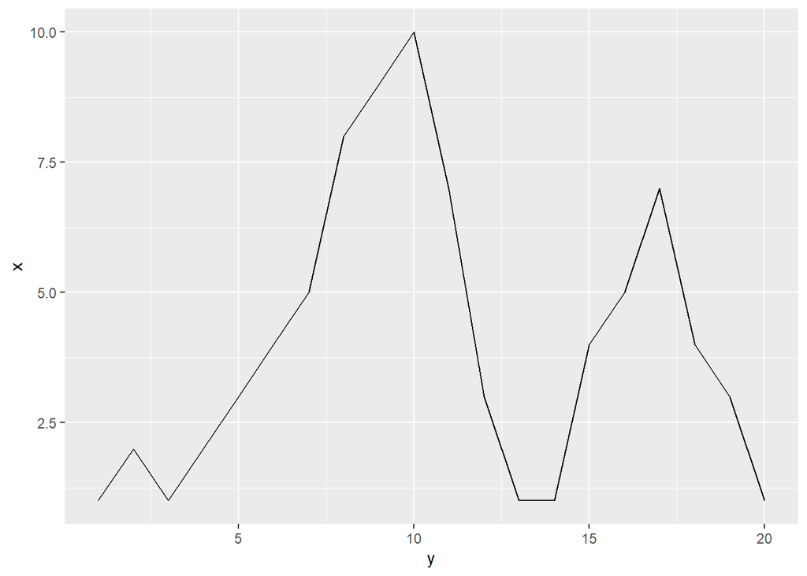

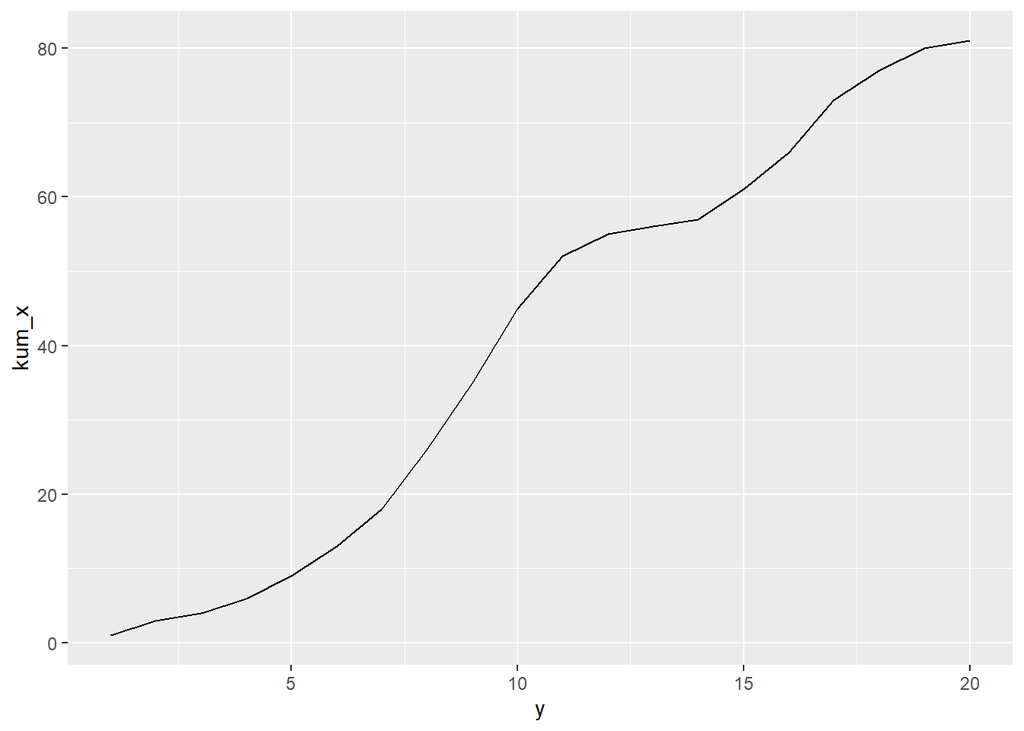

```r
x <- c(1, 2, 1, 2, 3, 4, 5, 8, 9, 10, 7, 3, 1, 1, 4, 5, 7, 4, 3, 1)
kum_x <- cumsum(x)

y <- seq(1, length(kum_x))
podatki <- tibble(x=x,y=y,kum_x=kum_x)

ggplot(podatki, aes(y, x)) + geom_line()
ggplot(podatki, aes(y, kum_x)) + geom_line()
```

Za izris grafov uporabimo knjižnico **ggplot**, ki je del knjižnice **tidyverse**.V zgornjem primeru opazimo, da v prvem grafu (navadnih podatkih) imamo dva ločena vrha, medtem ko pri kumulativnih podatkih vrha nista očitna, saj krivulja stalno narašča. Zato bomo v nadaljevanju spremenili vse kumulativne vrednosti v “dnevne vrednosti”, tako da bomo izračunali razlike vrednosti glede na prejšnji dan.

### Čiščenje manjkajočih vrednosti

Začnimo z nadomeščanjem manjkajočih vrednosti (NA). Pomagali si bomo s paketom *zoo*. Če pogledamo razpredelnico *stanje*, opazimo, da prvih 15 vrstic vsebuje le manjkajoče vrednosti. Te vrstice so za nas popolnoma neuporabne, zato jih odstranimo.

```r
stanje <- filter(stanje, day >= 7)
```

Nato, nam preostanejo le sporadične manjkajoče vrednosti. Za stolpca `day` in `date` lahko manjkajoče vrednosti popravimo tako, da vzamemo vrednost iz prejšnje vrstice in prištejemo 1 dan. Za to bomo uporabili funkcijo `lag`, ki prebere vrednost iz prejšnje vrstice. To seveda lahko storimo, ker imamo malo manjkajočih vrednosti, če bi imeli tudi po več zaporednih manjkajočih vrednosti bi lahko na novo zgenerirali datume ali pa ta postopek ponovili večkrat.

```r
stanje <- mutate(stanje,
                 date = ifelse(is.na(date), lag(date) + days(1), ymd(date)),
                 date = as_date(date),
                 day = ifelse(is.na(day), lag(day) + 1, day))
```

Datumi so sedaj popravljeni.

Za ostale spremenljivke pa nadomeščanje manjkajočih vrednosti v našem primeru ni tako enostavno. Standardne metode, kjer vse vrednosti zamenjamo z 0 ali pa s povprečno vrednostjo v tem primeru niso najbolj smiselne. Tu seUporabili bomo funkcijo `na.spline` iz paketa *zoo*, ki aproksimira manjkajoče vrednosti. Aproksimacije so realna števila izračunana iz sosednjih vrednosti. Aproksimacije bomo ponovno spremenili v cela števila s funkcijo `as.integer`.

```r
library(zoo)
stanje <- mutate(stanje, across(starts_with("state."), na.spline),
                 across(starts_with("state."), as.integer))
stanje
```

```
## # A tibble: 654 x 8
##      day date       state.in_hospital state.icu state.critical state.in_hospita~
##    <dbl> <date>                 <int>     <int>          <int>             <int>
##  1     7 2020-03-10                18         1              7                 0
##  2     8 2020-03-11                18         1              1                27
##  3     9 2020-03-12                17         2              1                31
##  4    10 2020-03-13                22         4              3                36
##  5    11 2020-03-14                29         4              3                39
##  6    12 2020-03-15                33         3              3                42
##  7    13 2020-03-16                32         5              3                49
##  8    14 2020-03-17                38         5              4                60
##  9    15 2020-03-18                43         5              4                69
## 10    16 2020-03-19                47         7              7                76
## # ... with 644 more rows, and 2 more variables:
## #   state.out_of_hospital.todate <int>, state.deceased.todate <int>
```

Na koncu pa še preverimo, če smo odstranili vse NA-je:

```r
apply(stanje, 2, function(x){sum(is.na(x))})
```

```
##                          day                         date
##                            0                            0
##            state.in_hospital                    state.icu
##                            0                            0
##               state.critical     state.in_hospital.todate
##                            0                            0
## state.out_of_hospital.todate        state.deceased.todate
##                            0                            0
```

### Spremenimo kumulativne vrednosti v navadne

Kumulativa *state.in_hospital.todate* nam ne pove veliko. Če gledamo samo razlike od prejšnjega dne, dobimo podatek o številu na novo sprejetih pacientih, kar je za nas veliko bolj zanimivo.

Za spremembo kumulativnih vrednosti v navadne vrednosti, moramo vsaki vrednosti odšteti vrednost prejšnjega dne. Torej moramo narediti obraten postopek, kot pri računanju kumulativnih vrednosti. Tudi v tem primeru bomo uporabili funkcijo `lag`. Funkcija `lag` bo za prvo vrstico vrnila NA, zato moramo biti previdni in začetni NA nadomestiti z 0.

```r
stanje <- stanje %>%
  mutate(across(ends_with(".todate"), ~ . -lag(.))) %>%
  mutate(across(ends_with(".todate"), ~ na.fill0(., fill = 0)))
```

Seveda, ste verjetno opazili, da je tabela v široki obliki, saj ima v glavi spremenljivko *state*, ki opisuje stanje pacientov. Spremenimo to v daljšo obliko za lažji izris z *ggplot*.

```r
stanje <- stanje %>%
  pivot_longer(cols = c(-day, -date),
               names_to = "stanje_pacienta",
               values_to = "st_oseb",
               names_prefix = "state.") %>%
  mutate(stanje_pacienta = str_replace(stanje_pacienta, ".todate", "_novi"))
stanje
```

```
## # A tibble: 3,924 x 4
##      day date       stanje_pacienta      st_oseb
##    <dbl> <date>     <chr>                  <dbl>
##  1     7 2020-03-10 in_hospital               18
##  2     7 2020-03-10 icu                        1
##  3     7 2020-03-10 critical                   7
##  4     7 2020-03-10 in_hospital_novi           0
##  5     7 2020-03-10 out_of_hospital_novi       0
##  6     7 2020-03-10 deceased_novi              0
##  7     8 2020-03-11 in_hospital               18
##  8     8 2020-03-11 icu                        1
##  9     8 2020-03-11 critical                   1
## 10     8 2020-03-11 in_hospital_novi          27
## # ... with 3,914 more rows
```

### Vizualizacija

Sedaj imamo podatke v dolgi obliki, tako da bomoza izris grafa uporabljali paket `ggplot`.`ggplot` se lahko integrira v “pipe”. Sedaj lahko prikažemo trende za vsa stanja pacientov. Spodnji graf prikazuje epidemiološka vala jeseni in pozimi 2020-2021 ter jeseni in pozimi 2021-2022. Poleg tega v kodi določimo tudi spremenljivko, ki bo določala katera stanja prikažemo. Zaenkrat bomo prikazali kar vsa:

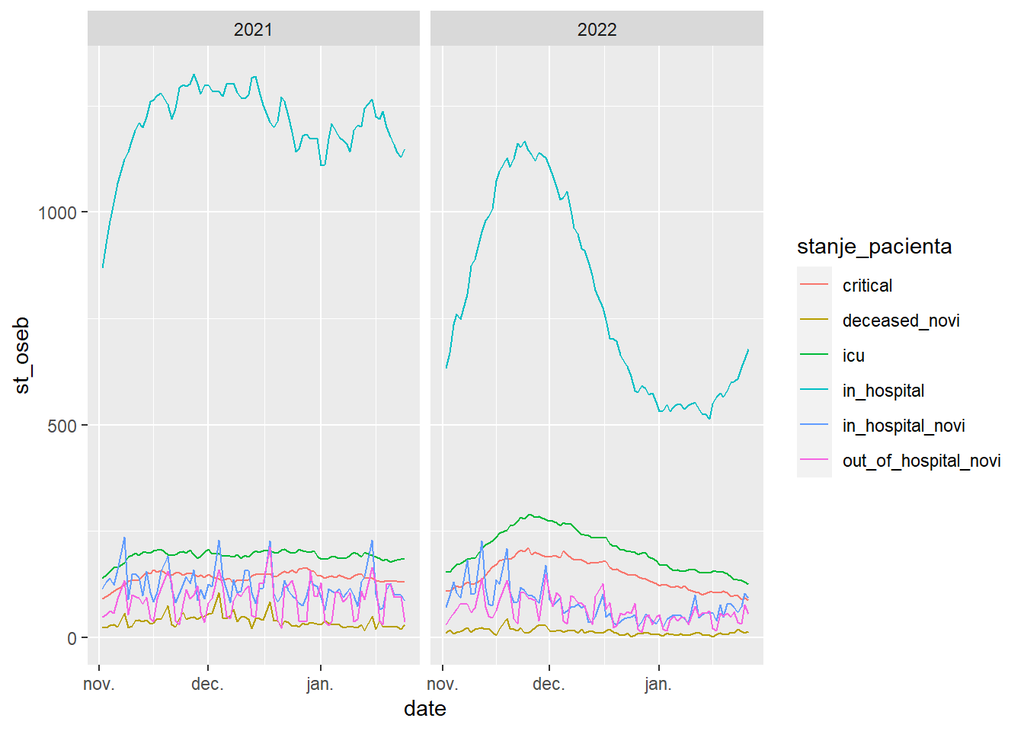

```r
prikazemo <- c("icu",
               "in_hospital",
               "critical",
                "in_hospital_novi",
                "out_of_hospital_novi",
                "deceased_novi")

stanje %>% mutate(val1 = ifelse(date > make_date(2020, 11, 1) & date < make_date(2021, 1, 25), 2021, 0),
                  val2 = ifelse(date > make_date(2021, 11, 1) & date < make_date(2022, 2, 25), 2022, 0),
                  val = val1 + val2) %>% #case_when?
  filter(stanje_pacienta %in% prikazemo, val > 0 ) %>%
  ggplot(., aes(x = date, y = st_oseb, color = stanje_pacienta)) + geom_line() +
  facet_wrap(.~ val, scales = "free_x" )
```

## Vizualizacija 2 - Število smrti za Covid v odvisnosti od starosti in spola

Sedaj, ko že bolje poznamo strukturo podatkov si bomo za drugo vizualizacijo pogledali še smrti zaradi Covida v odvisnosti od starosti in spola. Uporabljali bomo razpredelnico *smrti*, oziroma le zadnji zapis v tabeli, ker predstavlja najsodobnejši podatek.

```r
tail(smrti)
```

```
## # A tibble: 6 x 37
##     day date       `deceased.0-4.todate` `deceased.5-14.todate` `deceased.15-24~
##   <dbl> <date>     <lgl>                 <lgl>                             <dbl>
## 1   689 2022-01-21 NA                    NA                                    2
## 2   690 2022-01-22 NA                    NA                                    2
## 3   691 2022-01-23 NA                    NA                                    2
## 4   692 2022-01-24 NA                    NA                                   NA
## 5   693 2022-01-25 NA                    NA                                   NA
## 6   694 2022-01-26 NA                    NA                                   NA
## # ... with 32 more variables: deceased.25-34.todate <dbl>,
## #   deceased.35-44.todate <dbl>, deceased.45-54.todate <dbl>,
## #   deceased.55-64.todate <dbl>, deceased.65-74.todate <dbl>,
## #   deceased.75-84.todate <dbl>, deceased.85+.todate <dbl>,
## #   deceased.todate <dbl>, deceased.female.0-4.todate <lgl>,
## #   deceased.female.5-14.todate <lgl>, deceased.female.15-24.todate <dbl>,
## #   deceased.female.25-34.todate <dbl>, deceased.female.35-44.todate <dbl>, ...
```

Konkretno si bomo pogledali 691-ti zapis:

```r
smrti[691,]
```

```
## # A tibble: 1 x 37
##     day date       `deceased.0-4.todate` `deceased.5-14.todate` `deceased.15-24~
##   <dbl> <date>     <lgl>                 <lgl>                             <dbl>
## 1   682 2022-01-14 NA                    NA                                    2
## # ... with 32 more variables: deceased.25-34.todate <dbl>,
## #   deceased.35-44.todate <dbl>, deceased.45-54.todate <dbl>,
## #   deceased.55-64.todate <dbl>, deceased.65-74.todate <dbl>,
## #   deceased.75-84.todate <dbl>, deceased.85+.todate <dbl>,
## #   deceased.todate <dbl>, deceased.female.0-4.todate <lgl>,
## #   deceased.female.5-14.todate <lgl>, deceased.female.15-24.todate <dbl>,
## #   deceased.female.25-34.todate <dbl>, deceased.female.35-44.todate <dbl>, ...
```

Opazimo, da ima tudi ta vrstica nekaj manjkajočih podatkov.

### Čiščenje podatkov

Tudi v tem primeru je smiselno, da si zagotovimo, da imamo vse potrebne podatke za izbrani dan. Če podatek manjka je v tem primeru smiselno vzeti zadnjo kumulativo, ki je na voljo. Za polnjenje manjkajočih vrednosti bomo zato uporabljali funkcijo `na.locf`, ki stori ravno to. Začetni vrstici moramo prirediti vrednost 0, da bo `na.locf` delovala pravilno.

```r
smrti <- mutate(smrti,
                 date = ifelse(is.na(date), lag(date) + days(1), ymd(date)),
                 date = as_date(date),
                 day = ifelse(is.na(day), lag(day) + 1, day))

smrti[1, 3:37] <- 0
smrti <- mutate(smrti,across(starts_with("deceased."), na.locf ))
```

Sedaj, ko imamo zapolnjene podatke, lahko tabelo spremenimo v dolgo obliko in izrišemo graf. Naredimo vse skupaj.

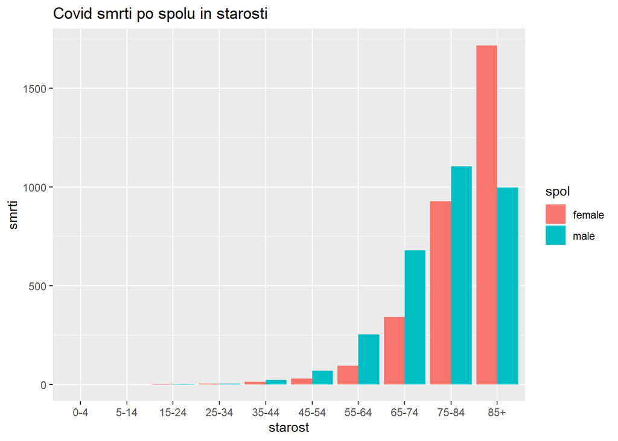

```r
smrti %>%
  filter(day == 691) %>%
    select(day, date, (contains("female") | contains("male")) & matches("\\d")) %>%
  pivot_longer(cols = contains("deceased."),
               names_to = c("spol", "starost"),
               names_sep = "\\.",
               names_prefix = "deceased.",
               values_to = "smrti") %>% #warning, ker zavržemo todate
  mutate( spol = factor(spol),
          starost = factor(starost, levels = unique(starost), ordered = T)) %>%
  ggplot(., aes(x = starost, y = smrti, fill = spol )) +
  geom_bar(stat = "identity", position = "dodge") +
  ggtitle("Covid smrti po spolu in starosti")
```